# hshoe stopping criteria investigation

Arnie Seong

01 September 2025

# 1 Purpose

Data generation:

- 4 covariates truly related to outcome (**linearly related**), 100 nuisance variables. Covariate values all generated from N(0, 1) via `torch_randn()`. N(0,1) noise
  - i.e. $y = -0.5 x_1 + 1x_2 -2 x_3 + 4 x_4 + \epsilon$
- 100 observations in training set, 25 in test set
- true coefficients: -0.5, 1, -2, 4, 0, 0, 0, 0, 0 …. (4 non-zero coefficients, 100 0 coefficients)
- only stopping criteria employed was max number of epochs (training epochs = 100k)

```r
# combine results files
fname_stem <- here::here("sims", "results", "hshoe_linreg_maxepochs")
sim_seeds <- c()
res_comp <- list()

for (i in 1:10){
  fname <- paste0(fname_stem, i, ".Rdata")
  load(fname)
  sim_seeds <- c(sim_seeds, contents$sim_params$sim_seeds)
  res_comp <- append(res_comp, contents$res)
}

res_comp <- setNames(res_comp, paste0("sim_", 1:length(res_comp)))
final_alphas <- t(sapply(res_comp,
       function(X) X$alpha_mat[nrow(X$alpha_mat),]
       ))
```

# 2 Mainline results: 100k training epochs

## 2.1 Using naive threshold of 0.05

Criteria for model inclusion: is the “dropout rate parameter” $\alpha$ lower than our T1 error threshold. This interprets $\alpha$ as a probability, which is not great ($\alpha$ is commonly > 1 for the nuisance variables)

### 2.1.1 Type II errors:

Total count of Type II errors over 100 simulated datasets:

```r
sum(final_alphas[, 1:4] > 0.05)
```

```
## [1] 53
```

Type II error rate:

```r
mean(final_alphas[, 1:4] > 0.05)
```

```
## [1] 0.1325
```

All errors are from the first covariate ($\beta = 0.5$). Table below shows $\alpha$ for first 4 covariates for all 100 simulated datasets.

|  | X1 | X2 | X3 | X4 |
| --- | --- | --- | --- | --- |
| sim_1 | 0.045 | 0.013 | 0.003 | 0.001 |
| sim_2 | 0.127 | 0.008 | 0.003 | 0.001 |
| sim_3 | 0.064 | 0.013 | 0.002 | 0.001 |
| sim_4 | 0.048 | 0.011 | 0.002 | 0.001 |
| sim_5 | 0.031 | 0.008 | 0.003 | 0.001 |
| sim_6 | 0.043 | 0.009 | 0.003 | 0.001 |
| sim_7 | 0.032 | 0.008 | 0.003 | 0.001 |
| sim_8 | 0.02 | 0.01 | 0.003 | 0 |
| sim_9 | 0.033 | 0.014 | 0.003 | 0.001 |
| sim_10 | 0.086 | 0.011 | 0.003 | 0.001 |

[output cut: 90 more lines]

### 2.1.2 T1 error

No spurious variables chosen when setting alpha threshold at 0.05.

```r
# count alphas < 0.05 among nuisance variables
sum(final_alphas[, 5:104] < 0.05)
```

```
## [1] 0
```

## 2.2 Interpreting $\alpha$ as posterior-based Wald statistic

A more principled approach might be to compare the dropout parameter $\alpha$ against the inverse of a $\chi^2$ distribution with 1 degree of freedom and applying Bonferroni. This is based on the idea that

1. **(to justify using $\chi^2 (1)$ distribution)** the $\alpha$ parameter is the inverse of the posterior-based Wald statistic discussed in [Liu, Li, Yu 2020](http://www.mysmu.edu/faculty/yujun/Research/ABT33.pdf) (referred to as LLY 2020);
2. **(to justify Bonferroni)** the mean-field assumption used in variational inference assumes independence between the individual $\alpha$ parameters ($\alpha_i = \dfrac{Var(\tilde{z_i})}{ \left[ E(\tilde{z_i}) \right] ^2}$.

### 2.2.1 LLY 2020

LLY 2020 propose the posterior-based Wald statistic

$$W = (\bar\theta -
\theta_0)'[V_{\theta \theta} (\bar\nu)]^{-1} (\bar\theta - \theta_0)
\overset{d}{\rightarrow} \chi^2(q_\theta)$$

- $\theta$ is the parameter(s) of interest ($\bar\theta$ refers to the posterior mean),
- $q_\theta$ the dimension of $\theta$,
- $V_{\theta \theta} (\bar\nu)$ the portion of the posterior covariance matrix relevant to $\theta$ ($\nu$ refers to all estimated parameters),

### 2.2.2 Results for posterior-based Wald interpretation of $\alpha$

#### 2.2.2.1 Type II error

```r
wald_thresh <- 1 / qchisq(1 - (0.05 / 104), df = 1)
t2_sum <- sum(final_alphas[, 1:4] > wald_thresh)
t2_sum # T2 errors
```

```
## [1] 28
```

Results: 28 errors total out of a possible 400 (4 true covariates, 100 simulations)

I.e. T2 error rate of 0.07.

#### 2.2.2.2 Type I error

T1 errors (out of 100 nuisance variables * 100 simulations):

```r
sum(final_alphas[, 5:104] < wald_thresh)
```

```
## [1] 2
```

so a T1 error rate of 0.0002

### 2.2.3 Problem with posterior Wald interpretation?

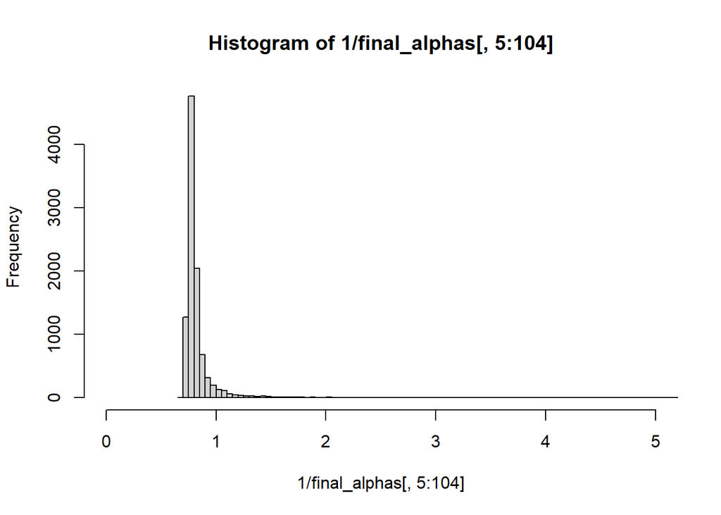

```r
hist(1/final_alphas[, 5:104], xlim = c(0, 5), breaks = 250)
```

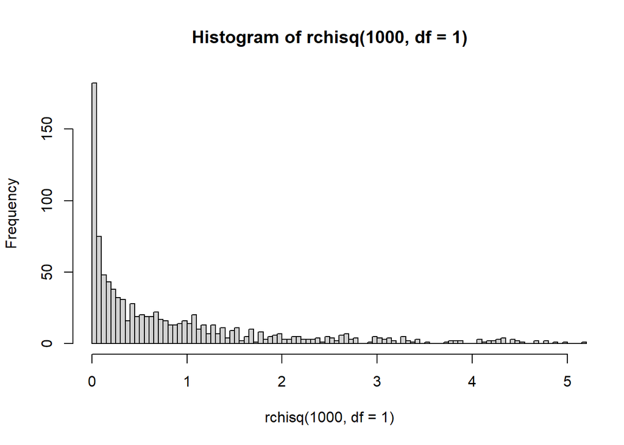

```r
hist(rchisq(1000, df=1), xlim = c(0, 5), breaks = 250)
```

The two do not match well. However, there are a few possible explanations:

1. variational inference is known to underestimate variance (which would push the mode to the right);
2. maybe explaining why there are NO values below 0.7: in LLY 2020, Theorem 3.1, it is clarified that the Bayesian $W$ and the Frequentist $Wald$ are not quite the same:

$$W = Wald + o_p(1)
\overset{d}{\rightarrow} \chi^2(q_\theta)$$

Last, we are just looking at the final training epochs. These simulations simply set a maximum number of 100k training epochs, so it’s possible that the network should have trained for a longer period of time.

### 2.2.4 notes / thoughts:

- any way to get ELBOs for competing models to approximate bayes factors? Is this even useful / desirable? Avoiding this kind of computation is kind of the reason we’re using NN’s in the first place….

# 3 Examination for reducing FP / FN?

Looking at different stopping criteria for training the network:

1. “convergence”
- **in NEXT analysis** (the results so far save results every 1000 epochs, not every epoch)
- of test MSE
- of train MSE
- of alphas
1. **test, train, test - train** MSE increasing
- particularly with test MSE > train MSE
1. rolling mean of the above,

## 3.1 test, train, test-train MSE increasing

```r
# did simulation have false positive / false negative?
FP_mat <- final_alphas[, 5:104] < wald_thresh
FN_mat <- final_alphas[, 1:4] > wald_thresh
err_df <- data.frame(
  "FP" = apply(FP_mat, 1, any),
  "FN" = apply(FN_mat, 1, any),
  "sim" = paste0("sim_", 1:nrow(FP_mat))
)

err_df$err_type <- ifelse(err_df$FN, "t2" , NA)
err_df$err_type <- ifelse(err_df$FP, "t1" , err_df$err_type)
err_df$err_type <- ifelse(err_df$FP + err_df$FN == 0, "none" , err_df$err_type)

# compile loss_mats from all simulations
res_arr <- sapply(
  res_comp,
  function(X) cbind(X$alpha_mat, X$loss_mat),
  simplify = "array"
)

# loss_arr dims:   1: epoch;   2: kl, mse_train, mse_test;   3: sim_#
loss_arr <- sapply(
  res_comp,
  function(X) X$loss_mat,
  simplify = "array"
)
# alph_arr dims:   1: epoch;   2: coefs   3: sim_#
alph_arr <- sapply(
  res_comp,
  function(X) X$alpha_mat,
  simplify = "array"
)

if (length(unique(sapply(res_arr, nrow))) > 1) {
  res_arr <- res_arr[11:100]
  res_arr <- simplify2array(res_arr)
  loss_arr <- loss_arr[11:100]
  loss_arr <- simplify2array(loss_arr)
  alph_arr <- alph_arr[11:100]
  alph_arr <- simplify2array(alph_arr)
  err_df <- err_df[11:100, ]
}

dimnames(res_arr)[[2]] <- c(
  paste0("alpha0", 1:9),
  paste0("alpha", 10:104),
  "kl", "mse_train", "mse_test"
)

# colnames(res_arr[, , 1])[105:107]
kl_mat <- res_arr[, 105, ]
train_mat <- res_arr[, 106, ]
test_mat <- res_arr[, 107, ]
tetr_mat <- test_mat - train_mat
```

### 3.1.1 train MSE plot

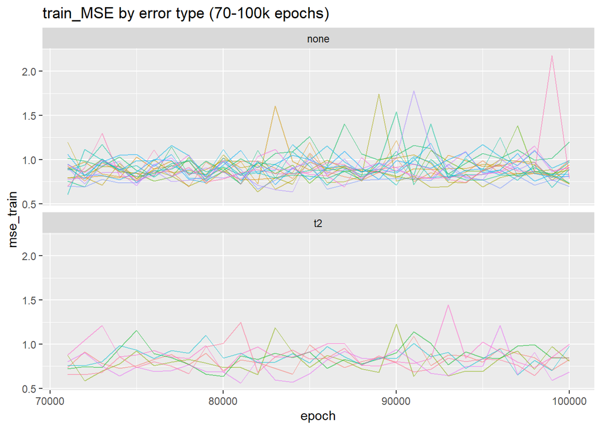

```r
ma_k <- 5

train_MA_df <- data.frame(
  apply(
    loss_arr[, 2, ],
    2,
    function(X) zoo::rollmean(X, k = ma_k)
  )
)

train_df <- data.frame(train_mat)
train_df$epoch <- as.numeric(rownames(train_mat))
train_MA_df$epoch <- train_df$epoch[ma_k : length(train_df$epoch)]

train_df_long <- train_df %>%
  pivot_longer(
    cols = !epoch,
    names_to = "sim",
    values_to = "mse_train")
train_MA_df_long <- train_MA_df %>%
  pivot_longer(
    cols = !epoch,
    names_to = "sim",
    values_to = "MA_mse_train")

train_df_long <- inner_join(train_df_long, err_df, by = "sim")
train_MA_df_long <- inner_join(train_MA_df_long, err_df, by = "sim")

# sample sims to be able to see
display_sims <- paste0("sim_", sample(1:100, 25))


train_df_long %>%
  # filter(err_type != "none") %>%
  filter(sim %in% display_sims) %>%
  filter(epoch > 70000) %>%
  ggplot(
    aes(
      y = mse_train,
      x = epoch,
      group = sim,
      color = sim)
  ) +
  geom_line(alpha = 0.5) +
  facet_wrap(~err_type, nrow = 3) +
  theme(legend.position = "none") +
  labs(
    title = "train_MSE by error type (70-100k epochs)"
  )
```

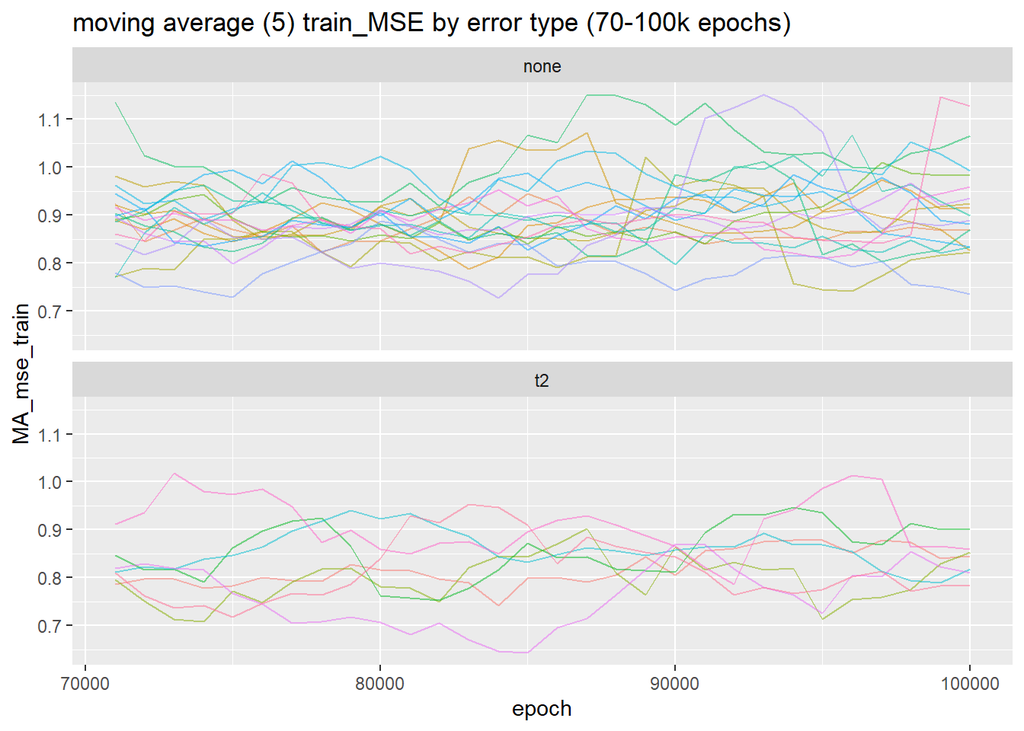

```r
train_MA_df_long %>%
  # filter(err_type != "none") %>%
  filter(sim %in% display_sims) %>%
  filter(epoch > 70000) %>%
  ggplot(
    aes(
      y = MA_mse_train,
      x = epoch,
      group = sim,
      color = sim)
  ) +
  geom_line(alpha = 0.5) +
  facet_wrap(~err_type, nrow = 3) +
  theme(legend.position = "none") +
  labs(
    title = paste0(
      "moving average (",
      ma_k,
      ") train_MSE by error type (70-100k epochs)"
    )
  )
```

### 3.1.2 test MSE

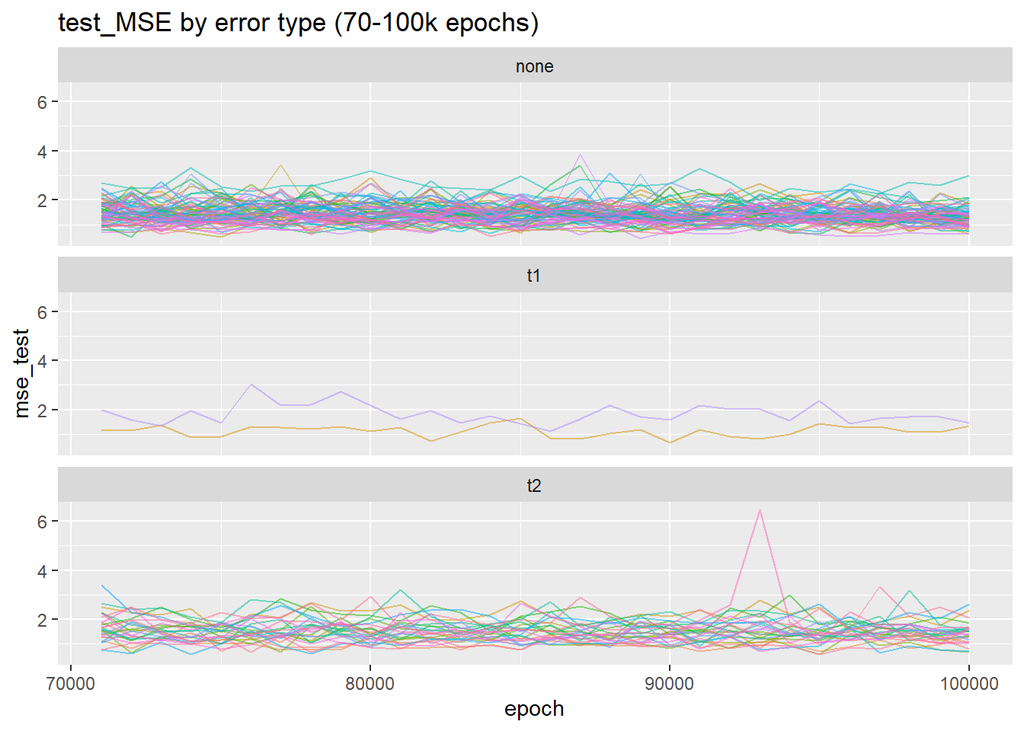

```r
test_MA_df <- data.frame(
  apply(
    loss_arr[, 3, ],
    2,
    function(X) zoo::rollmean(X, k = ma_k)
  )
)

test_df <- data.frame(test_mat)
test_df$epoch <- as.numeric(rownames(test_mat))
test_MA_df$epoch <- test_df$epoch[ma_k : length(test_df$epoch)]

test_df_long <- test_df %>%
  pivot_longer(
    cols = !epoch,
    names_to = "sim",
    values_to = "mse_test")
test_MA_df_long <- test_MA_df %>%
  pivot_longer(
    cols = !epoch,
    names_to = "sim",
    values_to = "MA_mse_test")

test_df_long <- inner_join(test_df_long, err_df, by = "sim")
test_MA_df_long <- inner_join(test_MA_df_long, err_df, by = "sim")

test_df_long %>%
  # filter(err_type != "none") %>%
  filter(epoch > 70000) %>%
  ggplot(
    aes(
      y = mse_test,
      x = epoch,
      group = sim,
      color = sim)
  ) +
  geom_line(alpha = 0.5) +
  facet_wrap(~err_type, nrow = 3) +
  theme(legend.position = "none") +
  labs(
    title = "test_MSE by error type (70-100k epochs)"
  )
```

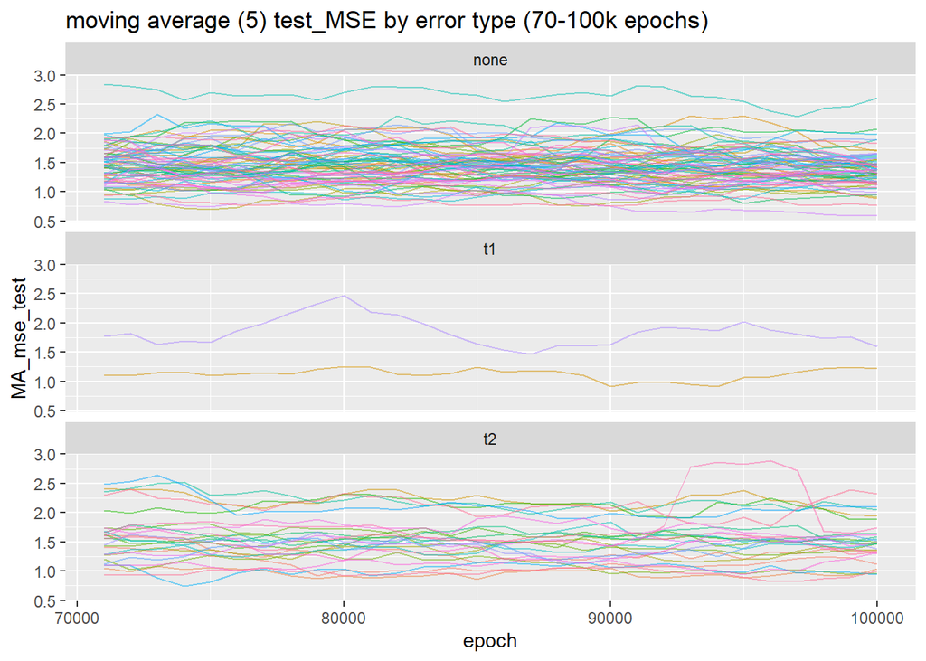

```r
test_MA_df_long %>%
  # filter(err_type != "none") %>%
  filter(epoch > 70000) %>%
  ggplot(
    aes(
      y = MA_mse_test,
      x = epoch,
      group = sim,
      color = sim)
  ) +
  geom_line(alpha = 0.5) +
  facet_wrap(~err_type, nrow = 3) +
  theme(legend.position = "none") +
  labs(
    title = paste0(
      "moving average (",
      ma_k,
      ") test_MSE by error type (70-100k epochs)"
    )
  )
```

### 3.1.3 test - train

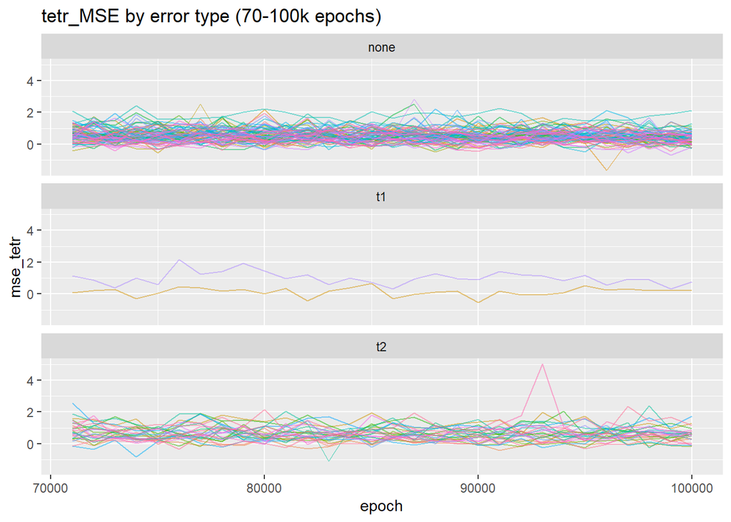

```r
tetr_MA_df <- data.frame(
  apply(
    loss_arr[, 3, ] - loss_arr[, 2, ],
    2,
    function(X) zoo::rollmean(X, k = ma_k)
  )
)

tetr_df <- data.frame(tetr_mat)
tetr_df$epoch <- as.numeric(rownames(tetr_mat))
tetr_MA_df$epoch <- tetr_df$epoch[ma_k : length(tetr_df$epoch)]

tetr_df_long <- tetr_df %>%
  pivot_longer(
    cols = !epoch,
    names_to = "sim",
    values_to = "mse_tetr")
tetr_MA_df_long <- tetr_MA_df %>%
  pivot_longer(
    cols = !epoch,
    names_to = "sim",
    values_to = "MA_mse_tetr")

tetr_df_long <- inner_join(tetr_df_long, err_df, by = "sim")
tetr_MA_df_long <- inner_join(tetr_MA_df_long, err_df, by = "sim")

tetr_df_long %>%
  # filter(err_type != "none") %>%
  filter(epoch > 70000) %>%
  ggplot(
    aes(
      y = mse_tetr,
      x = epoch,
      group = sim,
      color = sim)
  ) +
  geom_line(alpha = 0.5) +
  facet_wrap(~err_type, nrow = 3) +
  theme(legend.position = "none") +
  labs(
    title = "tetr_MSE by error type (70-100k epochs)"
  )
```

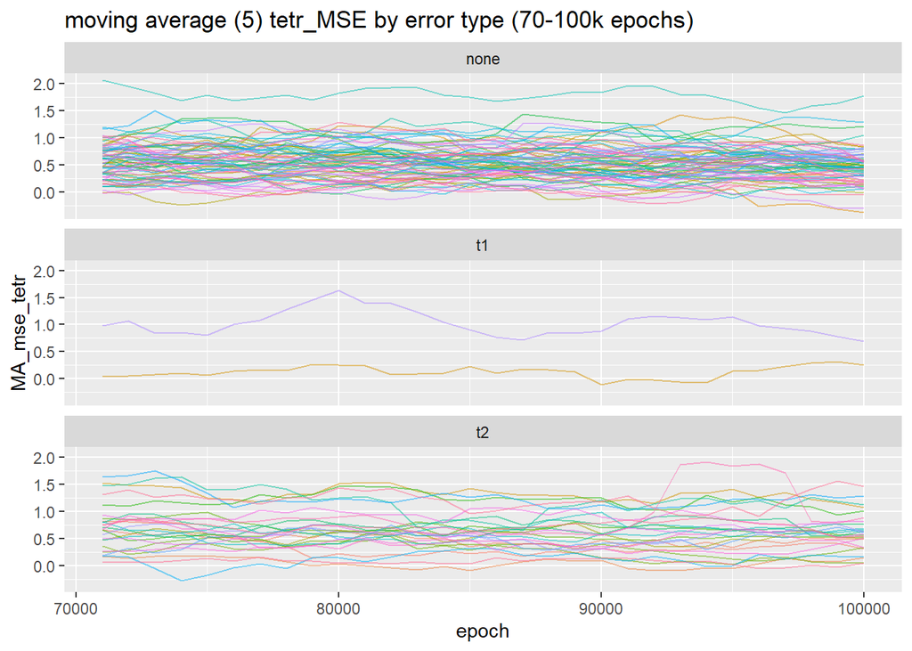

```r
tetr_MA_df_long %>%
  # filter(err_type != "none") %>%
  filter(epoch > 70000) %>%
  ggplot(
    aes(
      y = MA_mse_tetr,
      x = epoch,
      group = sim,
      color = sim)
  ) +
  geom_line(alpha = 0.5) +
  facet_wrap(~err_type, nrow = 3) +
  theme(legend.position = "none") +
  labs(
    title = paste0(
      "moving average (",
      ma_k,
      ") tetr_MSE by error type (70-100k epochs)"
    )
  )
```

### 3.1.4 KL

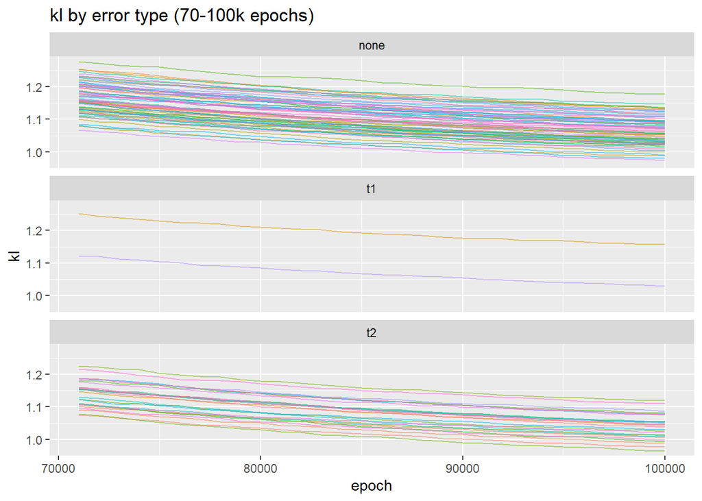

```r
kl_MA_df <- data.frame(
  apply(
    loss_arr[, 1, ],
    2,
    function(X) zoo::rollmean(X, k = ma_k)
  )
)

kl_df <- data.frame(kl_mat)
kl_df$epoch <- as.numeric(rownames(kl_mat))
kl_MA_df$epoch <- kl_df$epoch[ma_k : length(kl_df$epoch)]

kl_df_long <- kl_df %>%
  pivot_longer(
    cols = !epoch,
    names_to = "sim",
    values_to = "kl")
kl_MA_df_long <- kl_MA_df %>%
  pivot_longer(
    cols = !epoch,
    names_to = "sim",
    values_to = "MA_kl")

kl_df_long <- inner_join(kl_df_long, err_df, by = "sim")
kl_MA_df_long <- inner_join(kl_MA_df_long, err_df, by = "sim")

kl_df_long %>%
  # filter(err_type != "none") %>%
  filter(epoch > 70000) %>%
  ggplot(
    aes(
      y = kl,
      x = epoch,
      group = sim,
      color = sim)
  ) +
  geom_line(alpha = 0.5) +
  facet_wrap(~err_type, nrow = 3) +
  theme(legend.position = "none") +
  labs(
    title = "kl by error type (70-100k epochs)"
  )
```

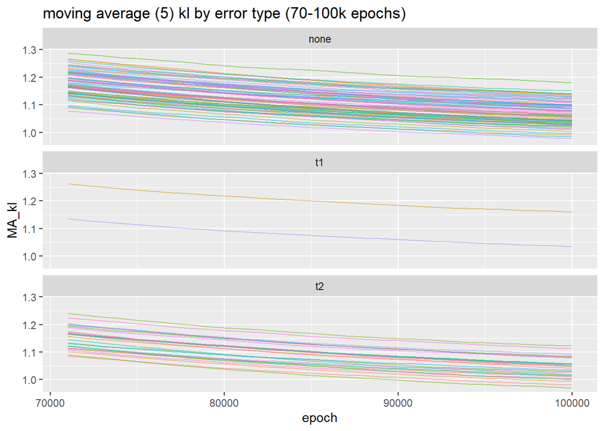

```r
kl_MA_df_long %>%
  # filter(err_type != "none") %>%
  filter(epoch > 70000) %>%
  ggplot(
    aes(
      y = MA_kl,
      x = epoch,
      group = sim,
      color = sim)
  ) +
  geom_line(alpha = 0.5) +
  facet_wrap(~err_type, nrow = 3) +
  theme(legend.position = "none") +
  labs(
    title = paste0(
      "moving average (",
      ma_k,
      ") kl by error type (70-100k epochs)"
    )
  )
```

### 3.1.5 conclusions from 100k training epoch sims

KL, train MSE, test MSE not really offering good clues as to T1 / T2 errors, at least looking at results from every 1k epochs for 100k training epochs

## 3.2 Reverse examination

- look at point when alphas reach threshold and stop changing decisions

```r
above_w <- apply(alph_arr, c(2, 3), function(X) X>wald_thresh)
dim(above_w)
```

```
## [1] 100 104 100
```

```r
change_w <- apply(above_w, c(2, 3), function(X) diff(X))
change_count_by_epoch <- apply(change_w, c(1, 3), function(X) sum(abs(X)))

rowSums(change_count_by_epoch)
```

```
##  2000  3000  4000  5000  6000  7000  8000  9000 10000 11000 12000 13000 14000
##     0     0     0     0     0     0     0     0     0     0     0     0     0
## 15000 16000 17000 18000 19000 20000 21000 22000 23000 24000 25000 26000 27000
##     0     0     0     0     1    13    26    45    57    48    41    41    28
## 28000 29000 30000 31000 32000 33000 34000 35000 36000 37000 38000 39000 40000
##    15    10    19    10     4     7     3     5     3     3     5     2     1
## 41000 42000 43000 44000 45000 46000 47000 48000 49000 50000 51000 52000 53000
##     2     0     2     2     1     2     3     1     0     1     1     0     3
## 54000 55000 56000 57000 58000 59000 60000 61000 62000 63000 64000 65000 66000
##     3     1     3     2     3     1     2     1     0     0     0     0     0
## 67000 68000 69000 70000 71000 72000 73000 74000 75000 76000 77000 78000 79000
##     0     0     0     0     0     0     1     0     2     0     2     0     1
## 80000 81000 82000 83000 84000 85000 86000 87000 88000 89000 90000 91000 92000
##     1     0     4     2     1     2     2     2     2     2     1     1     1
## 93000 94000 95000 96000 97000 98000 99000 1e+05
##     1     2     1     3     3     0     2     0
```

```r
sum(change_count_by_epoch[17:61, ])
```

```
## [1] 421
```

```r
sum(change_count_by_epoch)
```

```
## [1] 460
```

Most crosses of the wald-stat threshold occur between epochs 18k - 61k (421 crossings out of a total of 460 crossings).

- What is the behavior after 61k epochs?

```r
# count changes from False Neg to True Post (good)
sum(change_w[61:99, 1:4,] == -1)
```

```
## [1] 20
```

```r
# count changes from True Pos to False Neg (bad)
sum(change_w[61:99, 1:4,] == 1)
```

```
## [1] 19
```

```r
# how many of these changes are the same variable flipping?
varflips <- apply(
  change_w[61:99, 1:4, ],
  3,
  function(X) colSums(abs(X))
)
flips <- apply(varflips, 1, function(X) which(X != 0))
flips
```

```
## [[1]]
##  sim_12  sim_23  sim_26  sim_54  sim_70  sim_72 sim_100
##      12      23      26      54      70      72     100
##
## [[2]]
## named integer(0)
##
## [[3]]
## named integer(0)
##
## [[4]]
## named integer(0)
```

So these flips are all occurring in variable 1 (behavior to be expected). Simulations 12, 23, 26, 54, 70, 72, 100

### 3.2.1 comparison of flips vs noflips

#### 3.2.1.1 train_mse

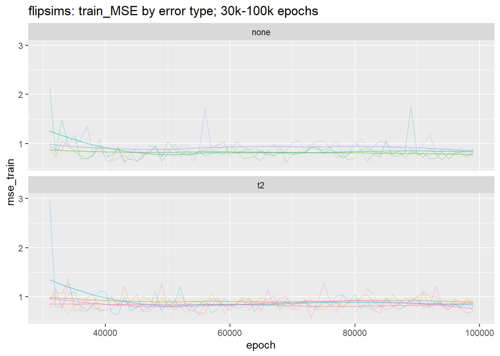

```r
flip_sims <- paste0("sim_", flips[[1]])
display_sims_noflips <- paste0("sim_", sample(setdiff(1:100, flips[[1]]), 20))

lo_epoch <- 30000
hi_epoch <- 100000
epoch_label <- paste0(lo_epoch/1000, "k-", hi_epoch/1000, "k epochs")

train_df_long %>%
  # filter(err_type != "none") %>%
  filter(sim %in% flip_sims) %>%
  filter(epoch > lo_epoch & epoch < hi_epoch) %>%
  ggplot(
    aes(
      y = mse_train,
      x = epoch,
      group = sim,
      color = sim)
  ) +
  geom_line(alpha = 0.25) +
  geom_line(stat = "smooth", alpha = 0.5) +
  facet_wrap(~err_type, nrow = 3) +
  theme(legend.position = "none") +
  labs(
    title = paste0("flipsims: train_MSE by error type; ", epoch_label)
  )
```

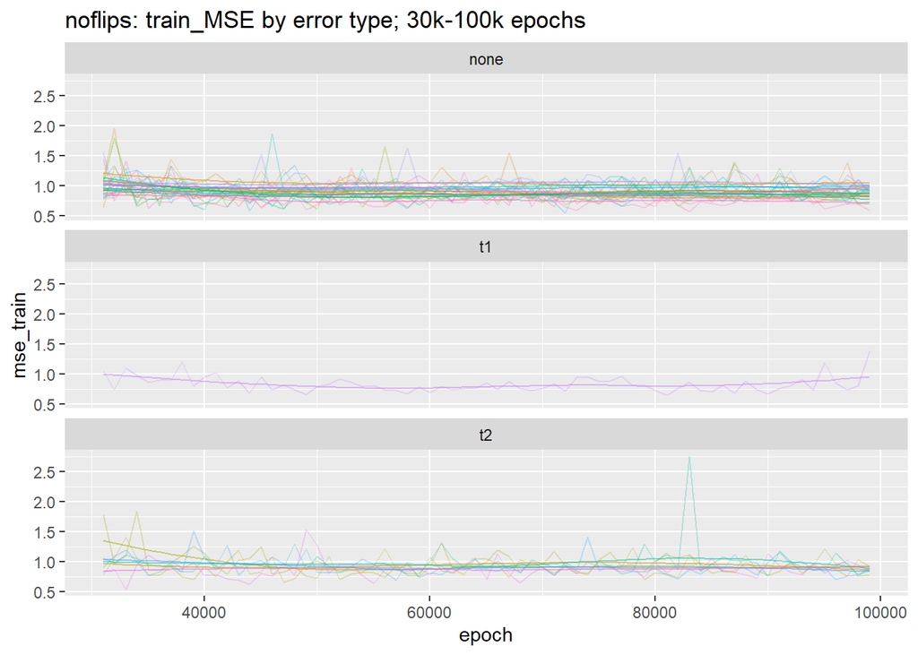

```r
train_df_long %>%
  # filter(err_type != "none") %>%
  filter(sim %in% display_sims_noflips) %>%
  filter(epoch > lo_epoch & epoch < hi_epoch) %>%
  ggplot(
    aes(
      y = mse_train,
      x = epoch,
      group = sim,
      color = sim)
  ) +
  geom_line(alpha = 0.25) +
  geom_line(stat = "smooth", alpha = 0.5) +
  facet_wrap(~err_type, nrow = 3) +
  theme(legend.position = "none") +
  labs(
    title = paste0("noflips: train_MSE by error type; ", epoch_label)
  )
```

#### 3.2.1.2 test_mse

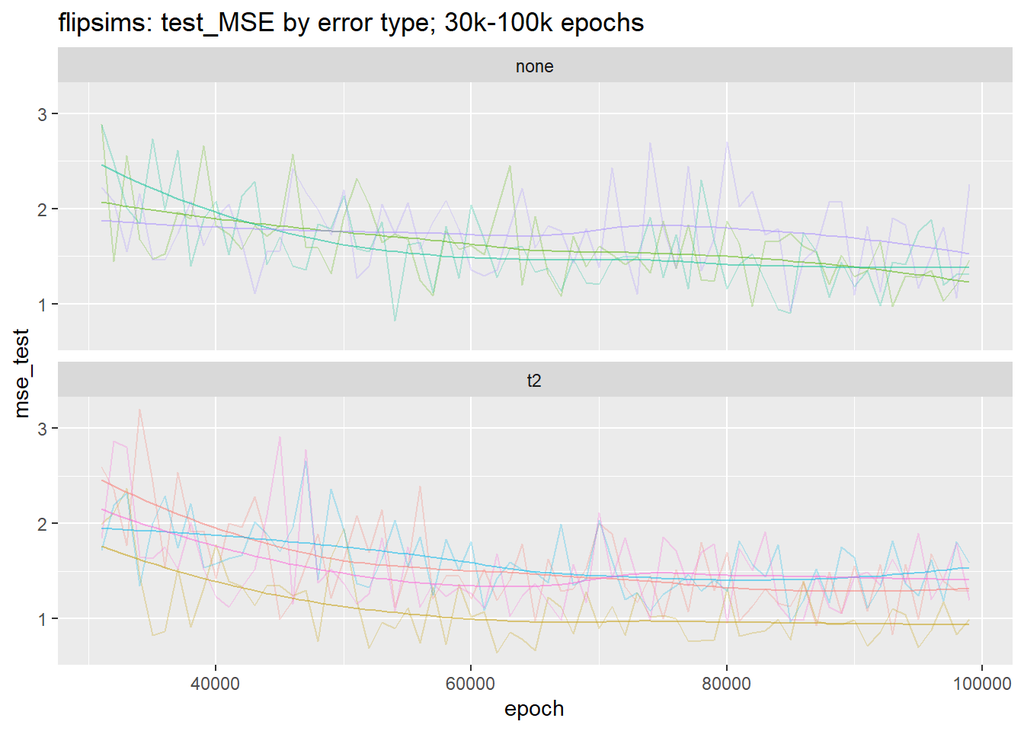

```r
test_df_long %>%
  # filter(err_type != "none") %>%
  filter(sim %in% flip_sims) %>%
  filter(epoch > lo_epoch & epoch < hi_epoch) %>%
  ggplot(
    aes(
      y = mse_test,
      x = epoch,
      group = sim,
      color = sim)
  ) +
  geom_line(alpha = 0.25) +
  geom_line(stat = "smooth", alpha = 0.5) +
  facet_wrap(~err_type, nrow = 3) +
  theme(legend.position = "none") +
  labs(
    title = paste0("flipsims: test_MSE by error type; ", epoch_label)
  )
```

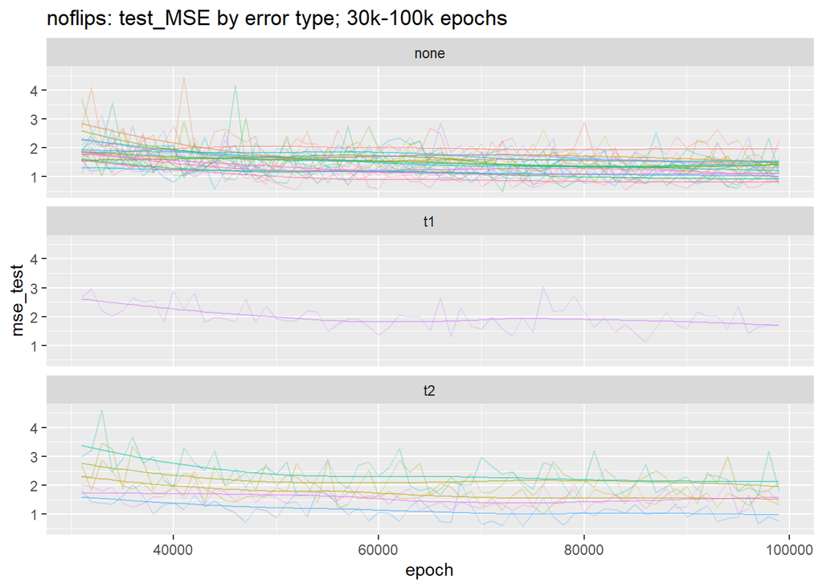

```r
test_df_long %>%
  # filter(err_type != "none") %>%
  filter(sim %in% display_sims_noflips) %>%
  filter(epoch > lo_epoch & epoch < hi_epoch) %>%
  ggplot(
    aes(
      y = mse_test,
      x = epoch,
      group = sim,
      color = sim)
  ) +
  geom_line(alpha = 0.25) +
  geom_line(stat = "smooth", alpha = 0.5) +
  facet_wrap(~err_type, nrow = 3) +
  theme(legend.position = "none") +
  labs(
    title = paste0("noflips: test_MSE by error type; ", epoch_label)
  )
```

#### 3.2.1.3 kl

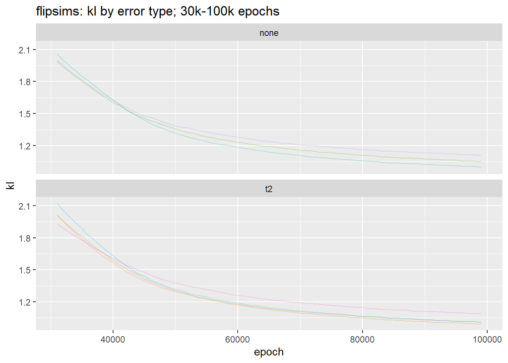

```r
kl_df_long %>%
  # filter(err_type != "none") %>%
  filter(sim %in% flip_sims) %>%
  filter(epoch > lo_epoch & epoch < hi_epoch) %>%
  ggplot(
    aes(
      y = kl,
      x = epoch,
      group = sim,
      color = sim)
  ) +
  geom_line(alpha = 0.25) +
  facet_wrap(~err_type, nrow = 3) +
  theme(legend.position = "none") +
  labs(
    title = paste0("flipsims: kl by error type; ", epoch_label)
  )
```

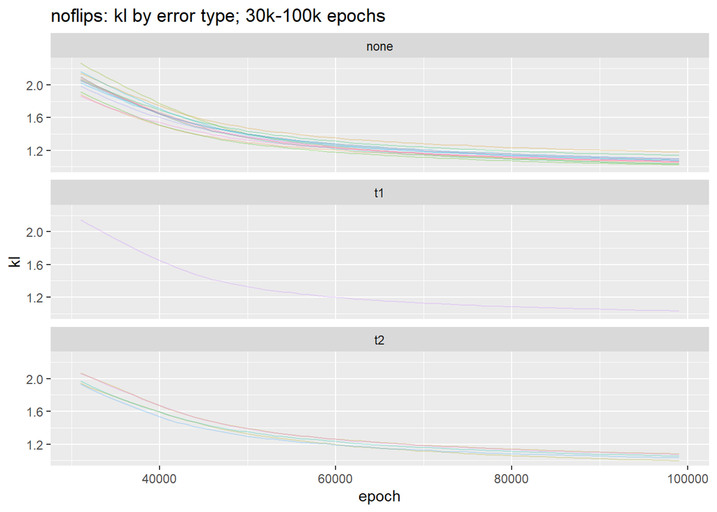

```r
kl_df_long %>%
  # filter(err_type != "none") %>%
  filter(sim %in% display_sims_noflips) %>%
  filter(epoch > lo_epoch & epoch < hi_epoch) %>%
  ggplot(
    aes(
      y = kl,
      x = epoch,
      group = sim,
      color = sim)
  ) +
  geom_line(alpha = 0.25) +
  facet_wrap(~err_type, nrow = 3) +
  theme(legend.position = "none") +
  labs(
    title = paste0("noflips: kl by error type; ", epoch_label)
  )
```

#### 3.2.1.4 test - train

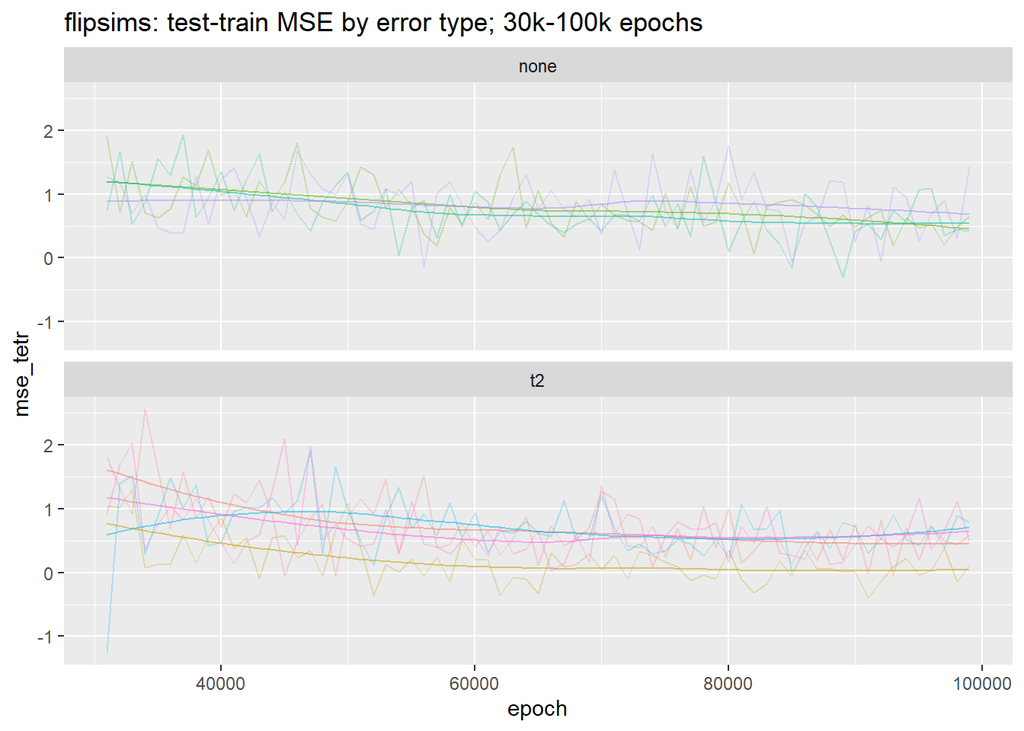

```r
tetr_df_long %>%
  # filter(err_type != "none") %>%
  filter(sim %in% flip_sims) %>%
  filter(epoch > lo_epoch & epoch < hi_epoch) %>%
  ggplot(
    aes(
      y = mse_tetr,
      x = epoch,
      group = sim,
      color = sim)
  ) +
  geom_line(alpha = 0.25) +
  geom_line(stat = "smooth", alpha = 0.5) +
  facet_wrap(~err_type, nrow = 3) +
  theme(legend.position = "none") +
  labs(
    title = paste0("flipsims: test-train MSE by error type; ", epoch_label)
  )
```

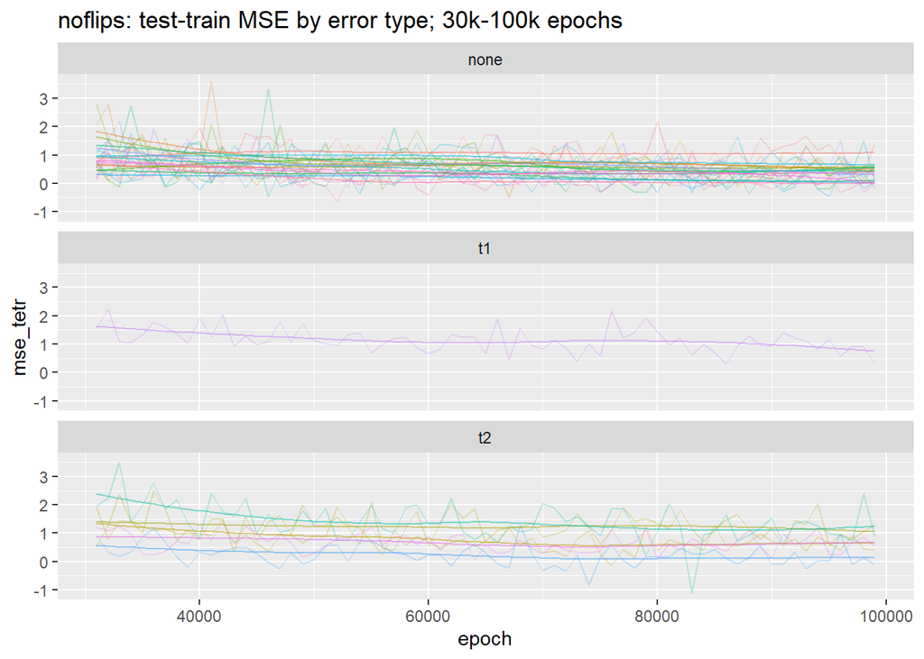

```r
tetr_df_long %>%
  # filter(err_type != "none") %>%
  filter(sim %in% display_sims_noflips) %>%
  filter(epoch > lo_epoch & epoch < hi_epoch) %>%
  ggplot(
    aes(
      y = mse_tetr,
      x = epoch,
      group = sim,
      color = sim)
  ) +
  geom_line(alpha = 0.25) +
  geom_line(stat = "smooth", alpha = 0.5) +
  facet_wrap(~err_type, nrow = 3) +
  theme(legend.position = "none") +
  labs(
    title = paste0("noflips: test-train MSE by error type; ", epoch_label)
  )
```

## 3.3 Conclusions

- train / test mse seems a bit too noisy to give us clues here as to when alphas stop flipping across the wald threshold.
  - Need to look at every iteration instead of every 1000 iterations
  - or look at the first-order differences directly?
- in any case, KL looks like the thing to look at — smoothly decreasing.
  - Epsilon used to assess convergence should be scaled by $n$.
- overall, training metrics appear fairly stable around 60k epochs

### 3.3.1 at 60k epochs:

```r
get_alphas_by_row <- function(row_num){
 t(sapply(res_comp,
         function(X) X$alpha_mat[row_num,]
         ))
}

alphas_60k <- get_alphas_by_row(60)
sum(alphas_60k[, 5:104] < wald_thresh)  # FP
```

```
## [1] 2
```

```r
sum(alphas_60k[, 1:4] > wald_thresh)    # FN
```

```
## [1] 30
```

### 3.3.2 over epochs

```r
errs_by_epoch <- matrix(NA, nrow = 100, ncol = 3)
colnames(errs_by_epoch) <- c("epoch", "T1", "T2")

for (epoch_row in 1:100){
  alphs <- get_alphas_by_row(epoch_row)
  errs_by_epoch[epoch_row, 1] <- epoch_row * 1000
  errs_by_epoch[epoch_row, 2] <- sum(alphs[, 5:104] < wald_thresh)  # FP
  errs_by_epoch[epoch_row, 3] <- sum(alphs[, 1:4] > wald_thresh)    # FN
}

err_rates_by_epoch <- errs_by_epoch
err_rates_by_epoch[, 2] <- errs_by_epoch[, 2] / (100 * 100)
err_rates_by_epoch[, 3] <- errs_by_epoch[, 3] / (4 * 100)

mykable(err_rates_by_epoch[1:10 * 10, ], cap = "error rates by epoch")
```

error rates by epoch

| epoch | T1 | T2 |
| --- | --- | --- |
| 10000 | 0.0000 | 1.0000 |
| 20000 | 0.0000 | 0.9650 |
| 30000 | 0.0007 | 0.1775 |
| 40000 | 0.0004 | 0.0975 |
| 50000 | 0.0003 | 0.0800 |
| 60000 | 0.0002 | 0.0750 |
| 70000 | 0.0002 | 0.0725 |
| 80000 | 0.0002 | 0.0750 |
| 90000 | 0.0002 | 0.0700 |
| 100000 | 0.0002 | 0.0700 |

Only marginal improvements when stopping after 50k epochs.